# Course Project 1 - Reproducible Research

Yue Liu

I am glad that you could take time to review my Course Project 1 of Reproducible Research. There will be four segments in this short report. Thank you for your time and patience.

## Introduction

It is now possible to collect a large amount of data about personal movement using activity monitoring devices such as a Fitbit, Nike Fuelband, or Jawbone Up. These type of devices are part of the “quantified self” movement - a group of enthusiasts who take measurements about themselves regularly to improve their health, to find patterns in their behavior, or because they are tech geeks. But these data remain under-utilized both because the raw data are hard to obtain and there is a lack of statistical methods and software for processing and interpreting the data.

The report will focus on the followings:  
* Data patten on a daily basis  
* Feature of data collected (e.g max, min, median of steps)  
* Data imputation and treatment  
* Distribution of data on different intervals  
* Creation of R markdown document which can be transformed into an HTML file

## R enviroment

Load R packages to begin:

```r
library(knitr)
library(ggplot2)
library(utils)
library(plyr)
library(lattice)
```

## Load the data and descriptive statistics

Set the working directory for downloaded data.  
Uncompress the original data file and create a dataframe called ‘Act_Data’:

```r
unzip("activity.zip")
Act_Data <- data.frame(read.csv('activity.csv',sep = ",",header = TRUE, na.strings ="NA"))
str(Act_Data)
```

```
## 'data.frame':    17568 obs. of  3 variables:
##  $ steps   : int  NA NA NA NA NA NA NA NA NA NA ...
##  $ date    : Factor w/ 61 levels "2012-10-01","2012-10-02",..: 1 1 1 1 1 1 1 1 1 1 ...
##  $ interval: int  0 5 10 15 20 25 30 35 40 45 ...
```

The introduction suggests three variables are included in activity: steps (integar),date (factor), and interval (integar). The descriptive statistics are listed as below. As date is a factor variable, thus frequency table is used rather than five-numbers to describe its distribution.The observations are evenly distributed on each date.

```r
summary(Act_Data)
```

```
##      steps                date          interval
##  Min.   :  0.00   2012-10-01:  288   Min.   :   0.0
##  1st Qu.:  0.00   2012-10-02:  288   1st Qu.: 588.8
##  Median :  0.00   2012-10-03:  288   Median :1177.5
##  Mean   : 37.38   2012-10-04:  288   Mean   :1177.5
##  3rd Qu.: 12.00   2012-10-05:  288   3rd Qu.:1766.2
##  Max.   :806.00   2012-10-06:  288   Max.   :2355.0
##  NA's   :2304     (Other)   :15840
```

```r
count(Act_Data, 'date')
```

```
##          date freq
## 1  2012-10-01  288
## 2  2012-10-02  288
## 3  2012-10-03  288
## 4  2012-10-04  288
## 5  2012-10-05  288
## 6  2012-10-06  288
## 7  2012-10-07  288
## 8  2012-10-08  288
## 9  2012-10-09  288
## 10 2012-10-10  288
## 11 2012-10-11  288
## 12 2012-10-12  288
## 13 2012-10-13  288
## 14 2012-10-14  288
```

[output cut: 47 more lines]

## Questions of interest

### What is mean total number of steps taken per day?

Recall the introduction, missing values are not considered in this part of data analysis. Thus a new dataframe is created without rows of missing values:

```r
NoNa_Act_Data <- na.omit(Act_Data)
```

#### Calculate the total number of steps taken per day

```r
total_steps <- aggregate(steps ~ date, NoNa_Act_Data, sum)
```

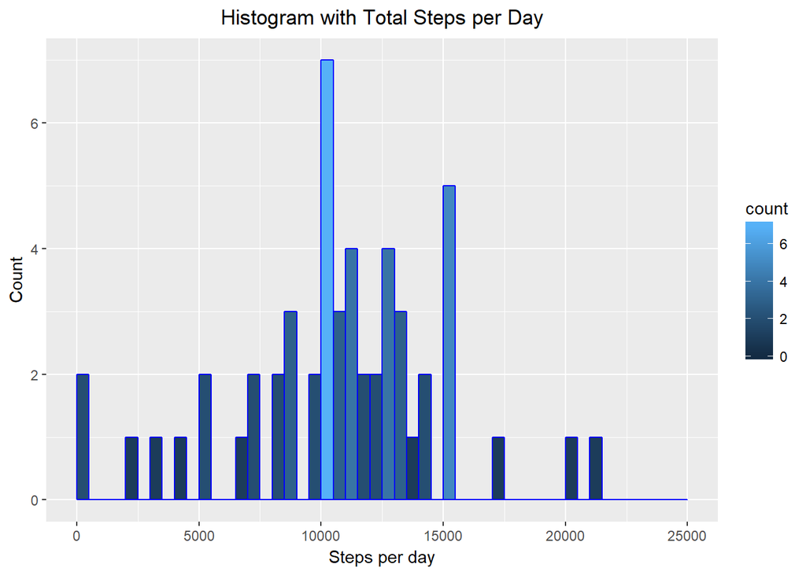

```r
ggplot(data=total_steps, aes(total_steps$steps)) +
  geom_histogram(breaks=seq(0, 25000, by =500),
                 col="blue",
                 aes(fill=..count..))+
  labs(title="Histogram with Total Steps per Day") +
  labs(x="Steps per day", y="Count")+
  theme(plot.title = element_text(hjust = 0.5))
```

#### Calculate and report the mean and median of the total steps

List the descriptive metrics of total steps by min, 1st Quantile, median, mean, 3rd Quantile, and Max.

```r
summary(total_steps$steps)
```

```
##    Min. 1st Qu.  Median    Mean 3rd Qu.    Max.
##      41    8841   10760   10770   13290   21190
```

```r
mean_total_steps <- mean(total_steps$steps)
median_total_steps <- median(total_steps$steps)
```

### What is the average daily activity pattern?

Create the vector as average number of steps taken on a 5-minute interval:

```r
avg_steps <- aggregate(steps ~ interval, NoNa_Act_Data, mean)
```

Make a time series plot of the calculated average number of steps above, across all days:

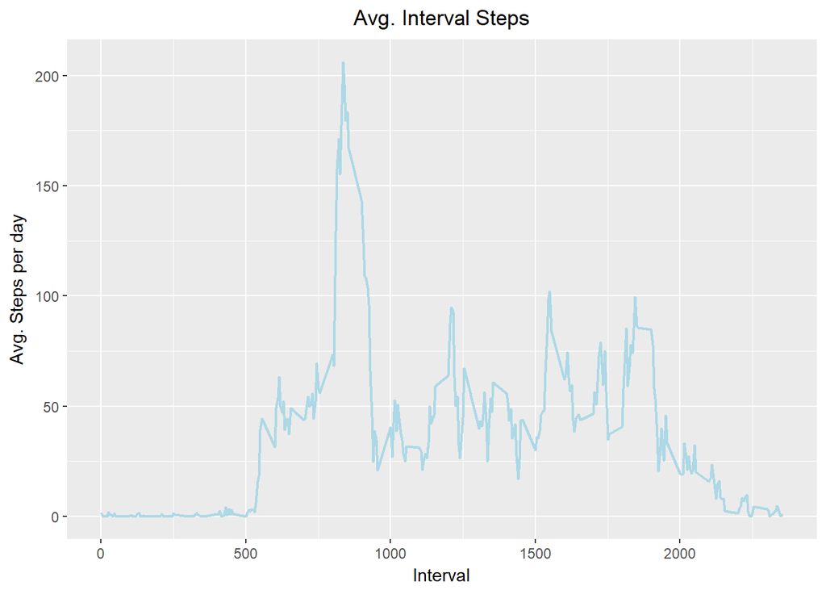

```r
ggplot(avg_steps$Interval, aes(x =avg_steps$interval , y=avg_steps$steps)) +
  geom_line(color="lightblue", size=0.8) +
  labs(title = "Avg. Interval Steps", x = "Interval", y = "Avg. Steps per day")+
  theme(plot.title = element_text(hjust = 0.5))
```

Find the interval which contains the maximum number of steps:

```r
avg_steps[order(avg_steps$steps,decreasing = TRUE),][1,]
```

```
##     interval    steps
## 104      835 206.1698
```

```r
max_avg_interval <- avg_steps[order(avg_steps$steps,decreasing = TRUE),][1,]$interval
max_avg_steps <- avg_steps[order(avg_steps$steps,decreasing = TRUE),][1,]$steps
```

It is the interval 835 which contains the maximum number of average steps as 206.1698113.

### Imputing missing values

#### Find the total number of missing values in data set.

To find the number of missing values in dataset, first to check the attributes with NAs.  
The only attribute with missing value is Steps according to data descriptive statistics below.

```r
sapply(Act_Data, function(x) sum(is.na(x)))
```

```
##    steps     date interval
##     2304        0        0
```

Now calcuate the missing value number in attribute steps.

```r
missing_num <- sum(is.na(Act_Data$steps))
missing_num
```

```
## [1] 2304
```

There are 2304 observations with missing steps.

#### Missing value imputation

The time series plot shows strong seasonality across different intervals. Thus using 5-minute interval average as  
plug-in value should be more reasonable.  
Create a vector called step_imputated as the fixed data set:

```r
step_imputated<- ifelse(is.na(Act_Data$steps)
                        , avg_steps$steps[match(Act_Data$interval
                                                , avg_steps$interval)], Act_Data$steps)


#Create a new dataset with step_imputated
Updt_Act_Data <- data.frame(cbind(step_imputated,Act_Data[,2:3]))
```

#### Make a histogram of total number of steps on imputated data

Recall codes used to populate total steps per day and the histogram:

```r
total_steps_fix <- aggregate(step_imputated ~ date, Updt_Act_Data, sum)
```

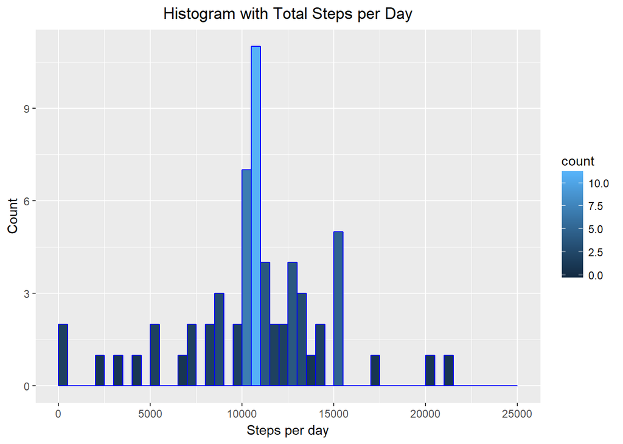

```r
ggplot(data=total_steps_fix, aes(total_steps_fix$step_imputated)) +
  geom_histogram(breaks=seq(0, 25000, by =500),
                 col="blue",
                 aes(fill=..count..))+
  labs(title="Histogram with Total Steps per Day") +
  labs(x="Steps per day", y="Count")+
  theme(plot.title = element_text(hjust = 0.5))
```

#### Calculate mean and median on imputated data

```r
summary(total_steps_fix$step_imputated)
```

```
##    Min. 1st Qu.  Median    Mean 3rd Qu.    Max.
##      41    9819   10770   10770   12810   21190
```

```r
mean_total_steps_fix <- mean(total_steps_fix$step_imputated)
median_total_steps_fix <- median(total_steps_fix$step_imputated)
```

The histogram of total steps per day has an obvious shift, while imputing missing data with 5-minute interval average has marginal impact on mean/median values.  
The reason to this subtle difference may result from the imputated value chosen, as 5-minute is a relatively  
small range. Choosing different impuated value would certainly affect descriptive metrics of the data.

### Are there differences in activity patterns between weekdays and weekends?

Add one more column called ‘wd’ as weekday/weekend in updated data set and make it a factor variable.

```r
Updt_Act_Data$wd <- sapply(weekdays(as.Date(Updt_Act_Data$date,format = "%Y-%m-%d"))
                           , function(x){
                             wdy <- ifelse(x=='Saturday'|x=='Sunday','weekend','weekday')
                             return(wdy)
                           })
Updt_Act_Data$wd <- as.factor(Updt_Act_Data$wd)
head(Updt_Act_Data)
```

```
##   step_imputated       date interval      wd
## 1      1.7169811 2012-10-01        0 weekday
## 2      0.3396226 2012-10-01        5 weekday
## 3      0.1320755 2012-10-01       10 weekday
## 4      0.1509434 2012-10-01       15 weekday
## 5      0.0754717 2012-10-01       20 weekday
## 6      2.0943396 2012-10-01       25 weekday
```

Create a panel plot which contains time series average number of steps of weekdays/weekend separately.

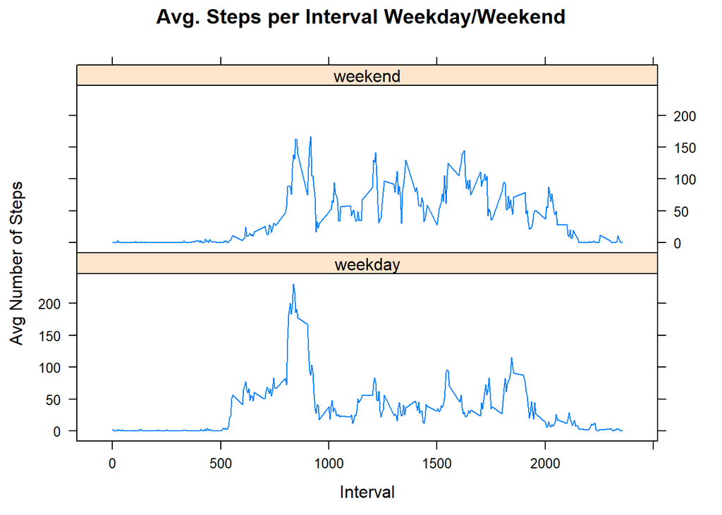

```r
Avg_step_wd <- aggregate(step_imputated~interval+wd,data=Updt_Act_Data,FUN=mean)

xyplot(step_imputated~interval|wd, data=Avg_step_wd, type="l",  layout = c(1,2)
       ,main="Avg. Steps per Interval Weekday/Weekend",
       ylab="Avg Number of Steps", xlab="Interval")
```

From the comparison between weekend and weekdays, it seems that activity reaches its peak earlier on weekdays.  
While the steps are rather stable across weekends, the targeted sample tend to work activily during morning, but  
their steps decrease sharply right after the peak and will remain a low level for rest of the day.